# Gravel Bike Geometry Classifier

A working document attempting to classify gravel bike frame geometries using some numerical methods

Jeffrey A. Walker

Created on 2022-06-07. Updated on 2022-07-08

Notes:

1. All bike data were taken from manufacturer’s web sites. Some missing data were computed based on other measures or taken from online reviews.
2. [bikinsights.com](https://bikeinsights.com/dashboard), geometrygeeks.bike and 99spokes.com are invaluable sites. This project offers a different way of comparing frames.

Some bike geometry links:

[The bike geometry Bible - Everything you need to know about the shape of your bike](https://off.road.cc/content/feature/the-bike-geometry-bible-everything-you-need-to-know-about-the-shape-of-your-bike)

[Frame Geometry Masterclass: Does The Evil Chamois Hagar Make ANY Sense?](https://www.cyclingabout.com/frame-geometry-masterclass-evil-chamois-hagar-gravel-bike/)

[MATTER of FACT: How to Understand Gravel Bike Geometry](https://www.teknecycling.com/collection/how-to-choose-a-gravel-bike-part-2-geometry)

```r
knitr::opts_chunk$set(echo = TRUE,
                      message = FALSE,
                      warning = FALSE,
                      knitr.kable.NA = '')
# wrangling packages
library(here) # here makes a project transportable
library(janitor) # clean_names
library(readxl) # read excel, duh!
library(data.table) # magical data frames
library(magrittr) # pipes
library(stringr) # string functions
library(forcats) # factor functions

# analysis packages
library(emmeans) # the workhorse for inference
library(nlme) # gls and some lmm
library(lme4) # linear mixed models
library(lmerTest) # linear mixed model inference
library(afex) # ANOVA linear models
library(glmmTMB) # generalized linear models
library(MASS) # negative binomial and some other functions
library(car) # model checking and ANOVA
library(DHARMa) # model checking
library(mvtnorm)

# graphing packages
library(ggsci) # color palettes
library(ggpubr) # publication quality plots
library(ggforce) # better jitter
library(cowplot) # combine plots
library(knitr) # kable tables
library(kableExtra) # kable_styling tables
library(ggdendro) # dendrogram
library(dendextend) # better dendrogram
library(ggiraph)
library(GGally)

# ggplot_the_model.R packages not loaded above
library(insight)
library(lazyWeave)

# use here from the here package
here <- here::here
# use clean_names from the janitor package
clean_names <- janitor::clean_names
# use transpose from data.table
transpose <- data.table::transpose

# load functions used by this text written by me
# ggplot_the_model.R needs to be in the folder "R"
# if you didn't download this and add to your R folder in your
# project, then this line will cause an error
#source_path <- here("R", "ggplot_the_model.R")
#source(source_path)

data_folder <- "data"
image_folder <- "images"
output_folder <- "output"
```

# 1 Functions

## 1.1 General

```r
deg_2_rad <- function(x){
  rad <- x*pi/180
  return(rad)
}
```

## 1.2 Bike Geometry

```r
get_axle_crown <- function(){

}

get_rake_h <- function(offset, hta){
  # the horizontal component of fork offset
  rake_h <- offset/sin(deg_2_rad(hta))
  return(rake_h)
}

get_ht_h <- function(hta, htl){
  # the horizontal component of head_tube
  # hta = head tube angle
  # htl = head tube length
  ht_h <- htl*cos(deg_2_rad(hta))
  return(ht_h)
}
get_ht_v <- function(hta, htl){
  # the vertical component of head_tube
  # hta = head tube angle
  # htl = head tube length
  ht_v <- htl*sin(deg_2_rad(hta))
  return(ht_v)
}


get_fork_angle <- function(offset, axle_crown, head_tube_angle){
  # angle of fork axle-crown axis to horizontal
  # beta is angle of fork axle-crow to offset line
  beta <- acos(offset/axle_crown)*180/pi
  # delta is angle from offset line to horizontal
  delta <- 90 - head_tube_angle
  fork_angle <- beta - delta
  return(rake_h)
}
```

```r
# Solace OM3 does not specify head tube length. This can be
# computed using specs of Whisky MCX fork assuming this is
# the fork used to spec wheelbase
head_tube_length <- function(axle_crown, rake, stack, wheelbase){
  rake_h <- get_rake_h(geobike[, fork_offset_rake],
                       geobike[, head_tube_angle])
  fork_angle <- get_fork_angle(geobike[, fork_offset_rake],
                               geobike[, fork_axle_crown],
                               geobike[, head_tube_angle])
}
```

```r
# Vagabond Genesis does not specify chainstay length.
get_chainstay_length <- function(rake, reach, stack, wheelbase,
                                 hta, htl, bbd){
  head_tube_h <- get_ht_h(hta, htl)
  head_tube_v <- get_ht_v(hta, htl)
  fork_v <- stack -  bbd -
    head_tube_v

  fork_h1 = fork_v/tan(deg_2_rad(hta))
  rake_h <- get_rake_h(rake,
                       hta)
  chainstay_h <- wheelbase - reach - head_tube_h - fork_h1 -
    rake_h

  chainstay <- sqrt(chainstay_h^2 + bbd^2)

  return(chainstay)
}
```

## 1.3 Importer

```r
# data_path <- here(data_folder, "ghost_grappler.txt")
# dt <- fread(data_path)
# bike_label = "Tumbleweed Stargazer 2022"
# bike_range = "b1:h21"

read_bike <- function(bike_label = "Breezer Radar X Pro 2022",
                      bike_range = "B1:I19"){
  data_file <- "bikes.xlsx"
  data_path <- here(data_folder, data_file)
  bike_wide <- read_excel(data_path,
                          sheet = bike_label,
                          range = bike_range) %>%
    data.table
  # re-read with coltype = numeric
  # col_type_list <- c("text", "text", rep("numeric", ncol(bike_wide)-2))
  # bike_wide <- read_excel(data_path,
  #                         sheet = bike_label,
  #                         range = bike_range,
  #                         col_types = col_type_list) %>%
  #   data.table


  bike_model <- substr(bike_label, 1, nchar(bike_label) - 5)
  model_year <- substr(bike_label,
                       nchar(bike_label) - 4,
                       nchar(bike_label))
  bike_wide <- bike_wide[, -2]
  bike <- data.table(
    model = bike_model,
    year = model_year,
    transpose(bike_wide,
              keep.names = "frame_size",
              make.names = 1)
  )
  keep_names <- c("model","frame_size", "seat_tube_length", "top_tube_effective_length", "head_tube_length", "seat_tube_angle", "head_tube_angle", "chainstay_length", "wheelbase", "bottom_bracket_drop", "fork_offset_rake", "stack", "reach", "standover", "stem_length", "handlebar_width", "crank_length", "wheel_size", "tire_width_spec", "tire_width_max")
  bike <- bike[, .SD, .SDcols = keep_names]

  # fill in missing
  bike[, chainstay_length :=
         ifelse(is.na(chainstay_length),
                get_chainstay_length(fork_offset_rake,
                                     reach,
                                     stack,
                                     wheelbase,
                                     head_tube_angle,
                                     head_tube_length,
                                     bottom_bracket_drop),
                chainstay_length)]

  # constructed measures
  bike[, model_size := paste(model, frame_size)]
  bike[, rear_center := sqrt(chainstay_length^2 - bottom_bracket_drop^2)] # horizontal
  bike[, front_center := wheelbase - rear_center] # horizontal
  bike[, seat_center := stack/tan(deg_2_rad(seat_tube_angle))]

  # ratios
  bike[, stack_reach := stack/reach]
  bike[, front_rear := front_center/rear_center]
  bike[, rear_wheelbase := rear_center/wheelbase]
  bike[, front_wheelbase := front_center/wheelbase]

  # decompositions
  # seat_tube_v and seat_tube_h are decomp of seat tube
  bike[, seat_tube_v := seat_tube_length *
         sin(deg_2_rad(seat_tube_angle))]
  bike[, seat_tube_h := seat_tube_length *
         cos(deg_2_rad(seat_tube_angle))]
  # seat_v and seat_h are decomp of seat positioned at stack height
  # tan(STA) = seat_h/seat_v
  bike[, seat_v := stack]
  bike[, seat_h := stack /
         tan(deg_2_rad(seat_tube_angle))]
  # head_v and head_h are decomp of head tube
  bike[, head_v := head_tube_length * sin(deg_2_rad(head_tube_angle))]
  bike[, head_h := head_tube_length * cos(deg_2_rad(head_tube_angle))]

  # landmarks with rear axle as origin
  bike[, x1 := 0] # rear axle
  bike[, y1 := 0]
  bike[, x2 := rear_center - seat_h] # seat at stack height
  bike[, y2 := stack - bottom_bracket_drop]
  bike[, x3 := rear_center + reach] # head tube top
  bike[, y3 := stack - bottom_bracket_drop]
  bike[, x4 := x3 + head_h] # head tube base
  bike[, y4 := y3 - head_v]
  bike[, x5 := wheelbase] # front axle
  bike[, y5 := 0]
  bike[, x6 := rear_center] # bottom bracket
  bike[, y6 := -bottom_bracket_drop]
  bike[, x7 := rear_center - seat_tube_h] # seat tube
  bike[, y7 := seat_tube_v]

  # landmarks_named
  bike[, rear_x := x1]
  bike[, rear_y := y1]
  bike[, seat_x := x2]
  bike[, seat_y := y2]
  bike[, head_x := x3]
  bike[, head_y := y3]
  bike[, crown_x := x4]
  bike[, crown_y := y4]
  bike[, front_x := x5]
  bike[, front_y := y5]
  bike[, bottom_x := x6]
  bike[, bottom_y := y6]
  bike[, seattube_x := x7]
  bike[, seattube_y := y7]

  return(bike)
}
```

## 1.4 Import

```r
data_path <- here(data_folder, "bike_list.txt")
bike_list <- fread(data_path)
geobike <- data.table(NULL)
for(i in 1:nrow(bike_list)){
  bike_i <- read_bike(bike_label = as.character(bike_list[i, "model"]),
                      bike_range = as.character(bike_list[i, "data_range"]))
  bike_i[, my_fit := ifelse(frame_size == c(bike_list[i, "my_fit"]), TRUE, FALSE)]
  geobike <- rbind(geobike, bike_i)
}

# my_fit: use 176 cm (I am 175.5)
# add Breezer small to my_fit
# geobike[model == "Breezer Radar X Pro" & frame_size == "48cm (S)", my_fit := TRUE]
# add Boone 54 to my_fit
# geobike[model == "Trek Boone 6" & frame_size == "54 cm", my_fit := TRUE]


# add column of shape id for plots
shape_list <- c(15,17,19,0,2)
n_shapes <- length(shape_list)
n_models <- length(unique(geobike[, model]))
n_recycles <- floor(n_models/n_shapes)
left_over <- n_models - n_recycles*n_shapes
model_2_shape_map <- c(rep(shape_list, n_recycles), shape_list[1:left_over])
geobike[, shape_id := model_2_shape_map[as.integer(as.factor(model))]]
```

## 1.5 Center landmarks at bottom bracket

```r
y_cols <- c("rear_x", "rear_y",
            "seat_x", "seat_y",
            "head_x", "head_y",
            "crown_x", "crown_y",
            "front_x", "front_y",
            "bottom_x", "bottom_y",
            "seattube_x", "seattube_y")

# center X at bottom bracket
geobike[, rear_x := rear_x - bottom_x]
geobike[, seat_x := seat_x - bottom_x]
geobike[, head_x := head_x - bottom_x]
geobike[, crown_x := crown_x - bottom_x]
geobike[, front_x := front_x - bottom_x]
geobike[, bottom_x := bottom_x - bottom_x]
geobike[, seattube_x := seattube_x - bottom_x]
```

# 2 Frame size classification – Initial

Three measures of frame size are computed

1. $\texttt{stack_reach_size_geomean}$ is the geometric mean of stack and reach.
2. $\texttt{rider_size}$ is the geometric mean of $\texttt{seat_tube_effective_length}$ and $\texttt{top_tube_effective_length}$. $\texttt{seat_tube_effective_length}$ is the size component related to the rider’s leg length. $\texttt{top_tube_effective_length}$ is the size component related to the rider’s torso and arm length.
3. $\texttt{centroid_size}$ of the three vertices of the front triangle created by the top of the virtual seat tube, the top of the head tube, and the bottom bracket.

```r
# stack + reach size
geobike[, stack_reach_size_euclid := sqrt(stack^2 + reach^2)]
geobike[, stack_reach_size_geomean := sqrt(stack * reach)]

# effective seat tube + effective top tube size
geobike[, seat_tube_effective_length :=
          sqrt((seat_x - bottom_x)^2 + (seat_y - bottom_y)^2)]
geobike[, rider_size := sqrt(seat_tube_effective_length *
                               top_tube_effective_length)]

# upper triangle centroid size
geobike[, centroid_x := (seat_x + bottom_x + head_x)/3]
geobike[, centroid_y := (seat_y + bottom_y + head_y)/3]
geobike[, centroid_size :=
          sqrt((seat_x - centroid_x)^2 +
          (seat_y - centroid_y)^2 +
          (bottom_x - centroid_x)^2 +
          (bottom_y - centroid_y)^2 +
          (head_x - centroid_x)^2 +
          (head_y - centroid_y)^2)]

# bike centroid size
geobike[, bike_centroid_x := (rear_x + seat_x + head_x + crown_x + front_x + bottom_x)/3]
geobike[, bike_centroid_y := (rear_y + seat_y + head_y + crown_y + front_y + bottom_y)/3]
geobike[, bike_centroid_size :=
          sqrt(
            (rear_x - bike_centroid_x)^2 +
              (rear_y - bike_centroid_y)^2 +
              (seat_x - bike_centroid_x)^2 +
              (seat_y - bike_centroid_y)^2 +
              (head_x - bike_centroid_x)^2 +
              (head_y - bike_centroid_y)^2 +
              (crown_x - bike_centroid_x)^2 +
              (crown_y - bike_centroid_y)^2 +
              (front_x - bike_centroid_x)^2 +
              (front_y - bike_centroid_y)^2 +
              (bottom_x - bike_centroid_x)^2 +
              (bottom_y - bike_centroid_y)^2
          )]
```

```r
size <- "bike_centroid_size"
size <- geobike[, get(size)]
c.x <- geobike[, bike_centroid_x]
c.y <- geobike[, bike_centroid_y]

# do not scale
# size <- 1
# c.x <- 0
# c.y <- 0

# centroid size based on seat/headtube/bottom bracket triangle
geobike[, rear_xs := (rear_x - c.x)/size]
geobike[, rear_ys := (rear_y - c.y)/size]
geobike[, seat_xs := (seat_x - c.x)/size]
geobike[, seat_ys := (seat_y - c.y)/size]
geobike[, head_xs := (head_x - c.x)/size]
geobike[, head_ys := (head_y - c.y)/size]
geobike[, crown_xs := (crown_x - c.x)/size]
geobike[, crown_ys := (crown_y - c.y)/size]
geobike[, front_xs := (front_x - c.x)/size]
geobike[, front_ys := (front_y - c.y)/size]
geobike[, bottom_xs := (bottom_x - c.x)/size]
geobike[, bottom_ys := (bottom_y - c.y)/size]
geobike[, seattube_xs := (seattube_x - c.x)/size]
geobike[, seattube_ys := (seattube_y - c.y)/size]
```

```r
my_fit <- geobike[my_fit == TRUE,]

shape_map <- setNames(geobike$shape_id, geobike$model)

nudge_percent <- 0.01
```

```r
gg1 <- ggplot(data = geobike,
             aes(x = centroid_size,
                 y = rider_size,
                 color = model)) +
  geom_point_interactive(aes(tooltip = model_size,
                             data_id = model_size,
                             shape = model),
                         show.legend = FALSE) +
  scale_shape_manual(values = shape_map)

nudge_pos <- nudge_percent*(max(my_fit$stack_reach_size_geomean) - min(my_fit$stack_reach_size_geomean))

gg2 <- ggplot(data = geobike,
             aes(x = stack_reach_size_geomean,
                 y = centroid_size,
                 color = model)) +
  geom_point_interactive(aes(tooltip = model_size,
                             data_id = model_size,
                             shape = model),
                         show.legend = FALSE) +
  scale_shape_manual(values = shape_map)

nudge_pos <- nudge_percent*(max(my_fit$stack_reach_size_geomean) - min(my_fit$stack_reach_size_geomean))

gg3 <- ggplot(data = my_fit,
             aes(x = stack_reach_size_geomean,
                 y = rider_size,
                 color = model,
                 label = model)) +
  geom_point_interactive(aes(tooltip = model_size,
                             data_id = model_size),
                         show.legend = FALSE) +
  geom_text(hjust = 0, nudge_x = nudge_pos, size = 2, show.legend = FALSE)
```

```r
girafe(ggobj = gg1)
```

[interactive chart not shown]

Figure 2.1: Hover over points to identify model and frame size

```r
girafe(ggobj = gg2)
```

[interactive chart not shown]

Figure 2.2: Hover over points to identify model and frame size

```r
girafe(ggobj = gg3)
```

[interactive chart not shown]

Figure 2.3: Hover over points to identify model and frame size

The goal here is to use the frame size measures to classify the bikes into size classes. First, here is the number of bike models that offer a specific number of frame sizes.

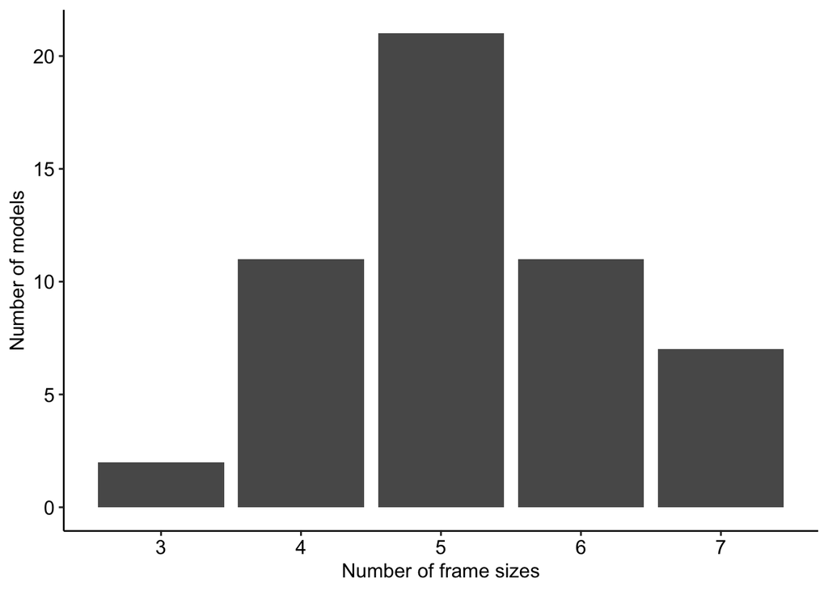

Figure 2.4: Distribution of bike models that offer a specific number of frame sizes

```r
frame_sizes_per_model <- geobike[, .(n_sizes = .N), by = .(model)]
size_dist <- frame_sizes_per_model[, .(n_models = .N), by = .(n_sizes)]
ggplot(data = size_dist,
       aes(x = n_sizes,
           y = n_models)) +
  geom_col() +
  ylab("Number of models") +
  xlab("Number of frame sizes") +
  theme_pubr()
```

```r
y_cols <- c("stack_reach_size_geomean", "rider_size", "centroid_size")

y_cols <- "centroid_size"

# 5 sizes
sizes <- c("extra-small", "small", "medium", "large", "extra-large")
n_sizes <- length(sizes)
size_groups <- kmeans(x = geobike[, .SD, .SDcols = y_cols],
                                  centers = n_sizes)
sizing <- size_groups$cluster
geobike[, size_cluster_5 := sizing]
cluster_means <- geobike[, .(cluster_mean = mean(stack_reach_size_geomean)),
                         by = .(size_cluster_5)] %>%
  dplyr::arrange(cluster_mean) %>%
  data.table()
cluster_means[, sizes := sizes]
cluster_means <- dplyr::arrange(cluster_means, size_cluster_5)
geobike[, frame_size_5 := cluster_means$sizes[size_cluster_5]]
geobike[, frame_size_5 := factor(frame_size_5,
                                 levels = sizes)]

# 7 sizes
sizes <- c("extra-small", "small", "small-medium", "medium", "medium-large", "large", "extra-large")
n_sizes <- length(sizes)
size_groups <- kmeans(x = geobike[, .SD, .SDcols = y_cols],
                                  centers = n_sizes)
sizing <- size_groups$cluster
geobike[, size_cluster_7 := sizing]
cluster_means <- geobike[, .(cluster_mean = mean(stack_reach_size_geomean)),
                         by = .(size_cluster_7)] %>%
  dplyr::arrange(cluster_mean) %>%
  data.table()
cluster_means[, sizes := sizes]
cluster_means <- dplyr::arrange(cluster_means, size_cluster_7)
geobike[, frame_size_7 := cluster_means$sizes[size_cluster_7]]
geobike[, frame_size_7 := factor(frame_size_7,
                                 levels = sizes)]
y_cols <- c("model", "frame_size", "frame_size_5", "frame_size_7")
#y_cols <- c("model", "frame_size", "frame_size_7")
# View(geobike[, .SD, .SDcols = y_cols])
```

```r
gg1 <- ggplot(data = geobike,
              aes(x = frame_size_5,
                  y = top_tube_effective_length,
                  color = model,
                  shape = model)) +
  geom_jitter_interactive(aes(tooltip = model_size,
                              data_id = model_size),
                          width = 0.2,
                          show.legend = FALSE) +
  scale_shape_manual(values = shape_map) +
  ylab("Top Tube, Effective Length (mm)")


gg2 <- ggplot(data = geobike,
              aes(x = frame_size_7,
                  y = top_tube_effective_length,
                  color = model,
                  shape = model)) +
  geom_jitter_interactive(aes(tooltip = model_size,
                              data_id = model_size),
                          width = 0.2,
                          show.legend = FALSE) +
  scale_shape_manual(values = shape_map) +
  ylab("Top Tube, Effective Length (mm)")

girafe(ggobj = gg1)
```

[interactive chart not shown]

Figure 2.5: Hover over points to identify model and frame size

```r
# girafe(ggobj = gg2)
```

Notes

1. Because the bikepacking/off-road bikes have extra high stack and/or extra long reach, the only extra-large bikes are bikepacking/off-road models and all of the all-road/race gravel bikes are classified into smaller bins then their specified size.
2. This suggests re-classifying within style classifications.

# 3 Style classification

```r
treed <- function(geobike_subset,
                  y_cols,
                  scale_it = TRUE,
                  center_it = TRUE,
                  hclust_method = "ward.D2"
){
  dd <- dist(scale(geobike_subset[, .SD, .SDcols = y_cols],
                   center = center_it,
                   scale = scale_it),
             method = "euclidean")
  dendro <- hclust(dd, method = hclust_method) %>%
    as.dendrogram() %>%
    place_labels(paste(geobike_subset[, model],
                       geobike_subset[, frame_size],
                       sep = ", "))

  return(dendro)
  # gg <- ggdendrogram(dendro)
  # return(gg)
}
```

## 3.1 Geometric frame shape

```r
var_labels <- c("Rear wheel X", "Rear wheel Y",
                "Seat at stack height, X",
                "Head tube X", "Head tube Y",
                "Fork crown X", "Fork crown Y",
                "Front wheel X", "Front wheel Y",
                "Bottom bracket X", "Bottom bracket Y")
data.table(
  Coordinates = var_labels
) %>%
  kable() %>%
  kable_styling(full_width = FALSE)
```

| Coordinates |
| --- |
| Rear wheel X |
| Rear wheel Y |
| Seat at stack height, X |
| Head tube X |
| Head tube Y |
| Fork crown X |
| Fork crown Y |
| Front wheel X |
| Front wheel Y |
| Bottom bracket X |
| Bottom bracket Y |

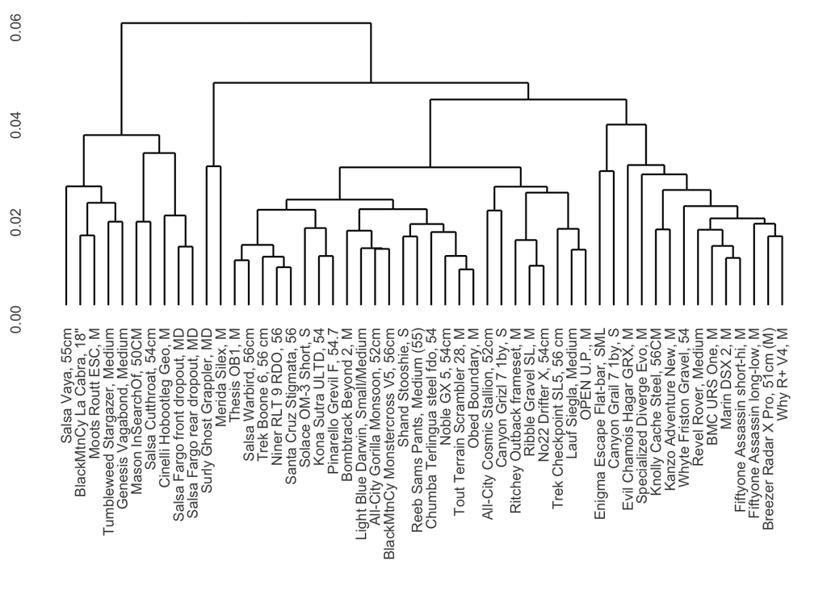

```r
y_cols <- c("rear_xs", "rear_ys",
            # seat_ys is redundant with head_ys
            "seat_xs",
            "head_xs", "head_ys",
            "crown_xs", "crown_ys",
            "front_xs", "front_ys",
            "bottom_xs", "bottom_ys")
geobike_subset <- geobike[my_fit == TRUE,]
scale_it <- FALSE
center_it <- FALSE
dendro <- treed(geobike_subset,
            y_cols,
            scale_it,
            center_it,
            hclust_method = "average")
gg <- ggdendrogram(dendro)

gg
```

Notes

1. Method – UPGMA method using landmark coordinates centered at the frame centroid and scaled by frame centroid size, for frames spec’d to my size.
2. Five clusters, from left to right
- bikepacking
- trail: drop-bar mtn bikes and flat-bar gravel bikes
- all-road
- progressive all-road
- trail: drop-bar mtn bikes and flat-bar gravel bikes

## 3.2 Traditional measures

```r
y_cols <- c("stack", "reach", "front_center", "rear_center", "bottom_bracket_drop", "fork_offset_rake", "head_tube_angle", "seat_tube_angle")
var_labels <- c("Stack", "Reach",
                "Front-center horizontal",
                "Rear-center horizontal",
                "Bottom bracket drop",
                "Fork offset",
                "Head tube angle",
                "Seat tube angle")
data.table(
  Variables = var_labels
) %>%
  kable() %>%
  kable_styling(full_width = FALSE)
```

| Variables |
| --- |
| Stack |
| Reach |
| Front-center horizontal |
| Rear-center horizontal |
| Bottom bracket drop |
| Fork offset |
| Head tube angle |
| Seat tube angle |

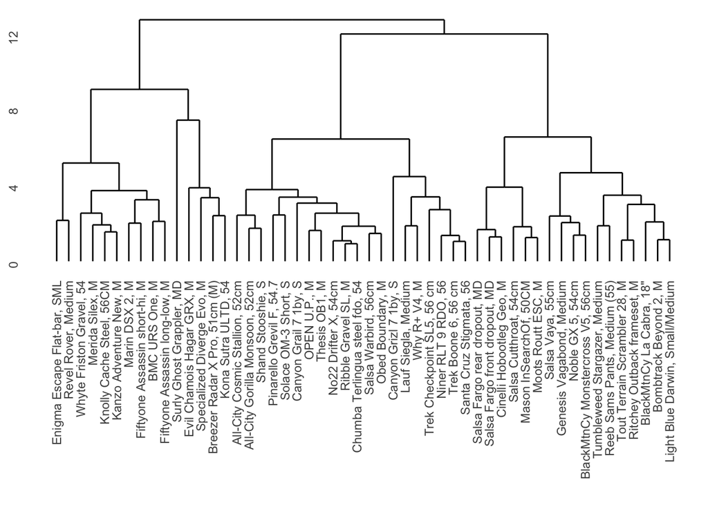

```r
y_cols <- c("stack", "reach", "front_center", "rear_center", "bottom_bracket_drop", "fork_offset_rake", "head_tube_angle", "seat_tube_angle")

geobike_subset <- geobike[my_fit == TRUE,]
scale_it <- TRUE
center_it <- TRUE
dendro <- treed(geobike_subset,
            y_cols,
            scale_it,
            center_it)
gg <- ggdendrogram(dendro)

gg
```

Notes

1. Method – Ward’s method using centered/scaled measures of frames spec’d for my height
2. Three major clusters, from left to right
- trail: drop-bar mtn bikes and flat-bar gravel bikes
- all-road and race gravel
- bikepacking

## 3.3 Style classification table

Using the traditional-measures tree above, the frames spec’d to my size can be classified into the three styles: All-road, Bikepacking, Trail

```r
options(knitr.kable.NA = '')
n_clusters <- 3
class_dendro <- cutree(dendro, k = n_clusters)
cluster_labels <- c("Trail", "Bikepacking", "All-road")
labels <- str_split_fixed(names(class_dendro), ",", 2)[,1]
style_class <- data.table(
  model = labels,
  style = cluster_labels[class_dendro]
)

# add style to geobike
geobike <- plyr::join(geobike, style_class, by = "model")
my_fit <- geobike[my_fit == TRUE,]

# dcast(setDT(DF), rowid(ID) ~ ID, value.var = "total")
cluster_labels <- c("All-road", "Bikepacking", "Trail")

style_table <-dcast(setDT(style_class), rowid(style) ~ style, value.var = "model")[, .SD, .SDcols = cluster_labels]

style_table %>%
  kable() %>%
  kable_styling(full_width = FALSE)
```

| All-road | Bikepacking | Trail |
| --- | --- | --- |
| Trek Boone 6 | Mason InSearchOf | Breezer Radar X Pro |
| Trek Checkpoint SL5 | Tumbleweed Stargazer | Evil Chamois Hagar GRX |
| Ribble Gravel SL | Tout Terrain Scrambler 28 | BMC URS One |
| Lauf Siegla | Ritchey Outback frameset | Surly Ghost Grappler |
| No22 Drifter X | Bombtrack Beyond 2 | Knolly Cache Steel |
| Niner RLT 9 RDO | Salsa Vaya | Kona Sutra ULTD |
| OPEN U.P. | Salsa Fargo front dropout | Specialized Diverge Evo |
| Thesis OB1 | Salsa Fargo rear dropout | Marin DSX 2 |
| All-City Gorilla Monsoon | Cinelli Hobootleg Geo | Whyte Friston Gravel |
| All-City Cosmic Stallion | Noble GX 5 | Enigma Escape Flat-bar |
| Chumba Terlingua steel fdo | BlackMtnCy Monstercross V5 | Merida Silex |
| Shand Stooshie | BlackMtnCy La Cabra | Fiftyone Assassin long-low |
| Salsa Warbird | Salsa Cutthroat | Fiftyone Assassin short-hi |
| Pinarello Grevil F | Moots Routt ESC | Revel Rover |
| Canyon Grail 7 1by | Light Blue Darwin | Kanzo Adventure New |
| Canyon Grizl 7 1by | Reeb Sams Pants |  |
| Obed Boundary | Genesis Vagabond |  |
| Solace OM-3 Short |  |  |
| Santa Cruz Stigmata |  |  |
| Why R+ V4 |  |  |

# 4 Pairwise

## 4.1 Stack and Reach

Notes

1. Stack and reach are the most common quick & dirty measure of frame size. These are imperfect measures of frame size because both measures are confounded by bike style – more bike-packing and mountain-bike inspired (“trail”) gravel bikes have high stack or long reach, or both, for their specified size class relative to all-road gravel bikes of the same size class.

```r
gg1 <- ggplot(data = geobike,
             aes(x = stack,
                 y = reach,
                 color = model)) +
  geom_point_interactive(aes(tooltip = model_size,
                             data_id = model_size,
                             shape = model),
                         show.legend = FALSE) +
   scale_shape_manual(values = shape_map)

nudge_pos <- nudge_percent*(max(my_fit$stack) - min(my_fit$stack))

gg2 <- ggplot(data = my_fit,
             aes(x = stack,
                 y = reach,
                 color = model,
                 label = model)) +
  geom_point_interactive(aes(tooltip = model_size,
                             data_id = model_size),
                         show.legend = FALSE) +
  geom_text(hjust = 0, nudge_x = nudge_pos, size = 2, show.legend = FALSE)

gg3 <- ggplot(data = my_fit,
             aes(x = stack,
                 y = reach,
                 color = style,
                 label = model)) +
  geom_point_interactive(aes(tooltip = model_size,
                             data_id = model_size),
                         show.legend = FALSE) +
  geom_text(hjust = 0, nudge_x = nudge_pos, size = 2, show.legend = FALSE)
```

```r
girafe(ggobj = gg1)
```

[interactive chart not shown]

Figure 4.1: Hover over points to identify model and frame size

```r
girafe(ggobj = gg2)
```

[interactive chart not shown]

Figure 4.2: Hover over points to identify model and frame size

```r
girafe(ggobj = gg3)
```

[interactive chart not shown]

Figure 4.3: Hover over points to identify model and frame size

## 4.2 Rear-center and Front-center

Notes

1. Rear-center and front-center *here* are the horizontal components. Combined, the two sum to the wheelbase.

```r
gg1 <- ggplot(data = geobike,
             aes(x = front_center,
                 y = rear_center,
                 color = model)) +
  geom_point_interactive(aes(tooltip = model_size,
                             data_id = model_size,
                             shape = model),
                         show.legend = FALSE) +
  scale_shape_manual(values = shape_map)

nudge_pos <- nudge_percent * (max(my_fit$front_center) -
                                min(my_fit$front_center))
gg2 <- ggplot(data = my_fit,
             aes(x = front_center,
                 y = rear_center,
                 color = model,
                 label = model)) +
  geom_point_interactive(aes(tooltip = model_size,
                             data_id = model_size),
                         show.legend = FALSE) +
  geom_text(hjust = 0, nudge_x = nudge_pos, size = 2, show.legend = FALSE)

gg3 <- ggplot(data = my_fit,
             aes(x = front_center,
                 y = rear_center,
                 color = style,
                 label = model)) +
  geom_point_interactive(aes(tooltip = model_size,
                             data_id = model_size),
                         show.legend = FALSE) +
  geom_text(hjust = 0, nudge_x = nudge_pos, size = 2, show.legend = FALSE)
```

```r
girafe(ggobj = gg1)
```

[interactive chart not shown]

Figure 4.4: Hover over points to identify model and frame size

```r
girafe(ggobj = gg2)
```

[interactive chart not shown]

Figure 4.5: Hover over points to identify model and frame size

```r
girafe(ggobj = gg3)
```

[interactive chart not shown]

Figure 4.6: Hover over points to identify model and frame size

## 4.3 Seat Tube Angle and Rear-Center

```r
y_cols <- c("seat_tube_angle", "stack", "reach", "rear_center", "front_center", "head_tube_angle")

ggpairs(geobike[, .SD, .SDcols = y_cols])

gghistogram(data = my_fit,
            x = "seat_tube_angle",
            color = "style",
            fill = "style")
```

[output not shown]

```r
gg1 <- ggplot(data = geobike,
             aes(x = front_center,
                 y = seat_tube_angle,
                 color = model)) +
  geom_point_interactive(aes(tooltip = model_size,
                             data_id = model_size,
                             shape = model),
                         show.legend = FALSE) +
  scale_shape_manual(values = shape_map)

nudge_pos <- nudge_percent * (max(my_fit$front_center) -
                                min(my_fit$front_center))
gg2 <- ggplot(data = my_fit,
             aes(x = front_center,
                 y = seat_tube_angle,
                 color = model,
                 label = model)) +
  geom_point_interactive(aes(tooltip = model_size,
                             data_id = model_size),
                         show.legend = FALSE) +
  geom_text(hjust = 0, nudge_x = nudge_pos, size = 2, show.legend = FALSE)

gg3 <- ggplot(data = my_fit,
             aes(x = front_center,
                 y = seat_tube_angle,
                 color = style,
                 label = model)) +
  geom_point_interactive(aes(tooltip = model_size,
                             data_id = model_size),
                         show.legend = FALSE) +
  geom_text(hjust = 0, nudge_x = nudge_pos, size = 2, show.legend = FALSE)

nudge_pos <- nudge_percent * (max(my_fit$rear_wheelbase) -
                                min(my_fit$rear_wheelbase))
gg4 <- ggplot(data = my_fit,
             aes(x = rear_wheelbase,
                 y = seat_tube_angle,
                 color = style,
                 label = model)) +
  geom_point_interactive(aes(tooltip = model_size,
                             data_id = model_size),
                         show.legend = FALSE) +
  geom_text(hjust = 0, nudge_x = nudge_pos, size = 2, show.legend = FALSE)
```

```r
girafe(ggobj = gg1)
```

[interactive chart not shown]

Figure 4.7: Hover over points to identify model and frame size

```r
girafe(ggobj = gg2)
```

[interactive chart not shown]

Figure 4.8: Hover over points to identify model and frame size

```r
girafe(ggobj = gg3)
```

[interactive chart not shown]

Figure 4.9: Hover over points to identify model and frame size

```r
girafe(ggobj = gg4)
```

[interactive chart not shown]

Figure 4.10: Hover over points to identify model and frame size

## 4.4 Head Tube Angle vs. Fork Offset

Notes

1. Head Tube Angle, Fork Offset, and Head Tube length are frame geometry contributions to trail but also affect toe-overlap in small bikes, especially with wide tires. I didn’t include trail in these analysis because it is a function of wheel plus tire diameter. I could use the spec’d wheel and tire and add this.

```r
gg1 <- ggplot(data = geobike,
             aes(x = head_tube_angle,
                 y = fork_offset_rake,
                 color = model)) +
  geom_point_interactive(aes(tooltip = model_size,
                             data_id = model_size,
                             shape = model),
                         show.legend = FALSE) +
  scale_shape_manual(values = shape_map)

nudge_pos <- nudge_percent * (max(my_fit$head_tube_angle) -
                                min(my_fit$head_tube_angle))
gg2 <- ggplot(data = my_fit,
             aes(x = head_tube_angle,
                 y = fork_offset_rake,
                 color = model,
                 label = model)) +
  geom_point_interactive(aes(tooltip = model_size,
                             data_id = model_size),
                         show.legend = FALSE) +
  geom_text(hjust = 0, nudge_x = nudge_pos, size = 2, show.legend = FALSE)

gg3 <- ggplot(data = my_fit,
             aes(x = head_tube_angle,
                 y = fork_offset_rake,
                 color = style,
                 label = model)) +
  geom_point_interactive(aes(tooltip = model_size,
                             data_id = model_size),
                         show.legend = FALSE) +
  geom_text(hjust = 0, nudge_x = nudge_pos, size = 2, show.legend = FALSE)

girafe(ggobj = gg1)
```

[interactive chart not shown]

Figure 4.11: Hover over points to identify model and frame size

```r
girafe(ggobj = gg2)
```

[interactive chart not shown]

Figure 4.11: Hover over points to identify model and frame size

```r
girafe(ggobj = gg3)
```

[interactive chart not shown]

Figure 4.11: Hover over points to identify model and frame size

# 5 PCA

Principal Component Analysis is a cheap way of exploring similarity of bike frames through different 2D views of a multidimensional space.

## 5.1 Coordinates

```r
y_cols <- c("rear_xs", "rear_ys",
            # seat_ys is redundant with head_ys
            "seat_xs",
            "head_xs", "head_ys",
            "crown_xs", "crown_ys",
            # front_ys is redundant with rear_ys
            "front_xs",
            "bottom_xs", "bottom_ys")
y_labs <- c("Rear wheel X", "Rear wheel Y",
            "Seat X",
            "Head tube X", "Head tube Y",
            "Fork Crown X", "Fork Crown Y",
            "Front wheel X",
            "Bottom Bracket X", "Bottom Bracket Y")

y_cols <- c("rear_x",
            "seat_x",
            "head_x", "head_y",
            "crown_x", "crown_y",
            "front_x",
            "bottom_y")
y_labs <- c("Rear wheel X",
            "Seat X",
            "Head tube X", "Head tube Y",
            "Fork Crown X", "Fork Crown Y",
            "Front wheel X",
            "Bottom Bracket Y")


geobike_subset <- geobike[my_fit == TRUE]
X <- geobike_subset[, .SD, .SDcols = y_cols] %>%
  as.matrix()

S <- cov(X)

geo_eigen <- eigen(S)

L <- geo_eigen$values
E <- geo_eigen$vector
scores <- X %*% E
pc1 <- scores[, 1]
pc2 <- scores[, 2]
pc3 <- scores[, 3]
geobike_subset[, pc1 := pc1]
geobike_subset[, pc2 := pc2]
geobike_subset[, pc3 := pc3]

coord_loadings <- cor(cbind(scores[,1:3], X))[-(1:3), 1:3]
row.names(coord_loadings) <- y_labs
table_cap <- "Correlations (or loadings) between PCs and coordinates centered at the bottom bracket with bike facing in positive X direction (right). Positive X correlations indicate higher PC is toward bike front. Positive Y correlations indicate higher PC is higher (more upward)."
coord_loadings %>%
  kable(digits = 2,
        caption = table_cap) %>%
  kable_styling(full_width = FALSE)
```

Table 5.1: Correlations (or loadings) between PCs and coordinates centered at the bottom bracket with bike facing in positive X direction (right). Positive X correlations indicate higher PC is toward bike front. Positive Y correlations indicate higher PC is higher (more upward).

| Rear wheel X | 0.47 | -0.44 | -0.21 |
| --- | --- | --- | --- |
| Seat X | 0.74 | -0.27 | 0.38 |
| Head tube X | -0.14 | -0.95 | 0.11 |
| Head tube Y | -0.92 | 0.22 | -0.31 |
| Fork Crown X | -0.30 | -0.94 | -0.14 |
| Fork Crown Y | -0.83 | 0.44 | 0.33 |
| Front wheel X | -0.78 | -0.57 | 0.16 |
| Bottom Bracket Y | -0.06 | 0.25 | -0.30 |

```r
gg1 <- ggplot(data = geobike_subset,
              aes(x = pc1,
                  y = pc2,
                  color = model,
                  shape = model)) +
  geom_point_interactive(aes(tooltip = model_size,
                             data_id = model_size),                          show.legend = FALSE) +
  scale_shape_manual(values = shape_map) +
  coord_fixed()

gg1b <- ggplot(data = geobike_subset,
              aes(x = pc1,
                  y = pc2,
                  color = style,
                  shape = model)) +
  geom_point_interactive(aes(tooltip = model_size,
                             data_id = model_size),                          show.legend = FALSE) +
  scale_shape_manual(values = shape_map) +
  coord_fixed()

gg2 <- ggplot(data = geobike_subset,
              aes(x = pc2,
                  y = pc3,
                  color = model,
                  shape = model)) +
  geom_point_interactive(aes(tooltip = model_size,
                             data_id = model_size),                          show.legend = FALSE) +
  scale_shape_manual(values = shape_map) +
  coord_fixed()

gg2b <- ggplot(data = geobike_subset,
              aes(x = pc2,
                  y = pc3,
                  color = style,
                  shape = model)) +
  geom_point_interactive(aes(tooltip = model_size,
                             data_id = model_size),                          show.legend = FALSE) +
  scale_shape_manual(values = shape_map) +
  coord_fixed()

gg3 <- ggplot(data = geobike_subset,
              aes(x = pc1,
                  y = pc3,
                  color = model,
                  shape = model)) +
  geom_point_interactive(aes(tooltip = model_size,
                             data_id = model_size),                          show.legend = FALSE) +
  scale_shape_manual(values = shape_map) +
  coord_fixed()

gg3b <- ggplot(data = geobike_subset,
              aes(x = pc1,
                  y = pc3,
                  color = style,
                  shape = model)) +
  geom_point_interactive(aes(tooltip = model_size,
                             data_id = model_size),                          show.legend = FALSE) +
  scale_shape_manual(values = shape_map) +
  coord_fixed()
```

Notes

```r
girafe(ggobj = gg1b)
```

[interactive chart not shown]

Figure 5.1: Hover over points to identify model and frame size

Notes

1. High PC2 describes a frame with small reach.
2. PC3 describes noise

```r
girafe(ggobj = gg2b)
```

[interactive chart not shown]

Figure 5.2: Hover over points to identify model and frame size

Notes

```r
girafe(ggobj = gg3b)
```

[interactive chart not shown]

Figure 5.3: Hover over points to identify model and frame size

## 5.2 Traditional measures and angles

Notes:

1. PCA using the centered and scaled measures used to compute the dendrogram above and the classification.

```r
y_cols <- c("stack", "reach", "front_center", "rear_center", "bottom_bracket_drop", "fork_offset_rake", "head_tube_angle", "seat_tube_angle")
y_labs <- c("stack", "reach", "front center", "rear center", "bottom bracket drop", "fork offset", "head tube angle", "seat tube angle")

geobike_subset <- geobike[my_fit == TRUE]
X <- geobike_subset[, .SD, .SDcols = y_cols] %>%
  scale()

S <- cov(X)

geo_eigen <- eigen(S)

L <- geo_eigen$values
E <- geo_eigen$vector
scores <- X %*% E
geobike_subset[, pc1 := scores[, 1]]
geobike_subset[, pc2 := scores[, 2]]
geobike_subset[, pc3 := scores[, 3]]


coord_loadings <- cor(cbind(scores[,1:3], X))[-(1:3), 1:3]
row.names(coord_loadings) <- y_labs
table_cap <- "Correlations (or loadings) between PCs and traditional frame measures."

coord_loadings %>%
  kable(digits = 2,
        caption = table_cap) %>%
  kable_styling(full_width = FALSE)
```

Table 5.2: Correlations (or loadings) between PCs and traditional frame measures.

| stack | 0.71 | -0.31 | 0.20 |
| --- | --- | --- | --- |
| reach | 0.32 | 0.84 | 0.25 |
| front center | 0.91 | 0.34 | 0.23 |
| rear center | 0.47 | -0.59 | -0.19 |
| bottom bracket drop | 0.17 | 0.44 | -0.70 |
| fork offset | 0.44 | -0.35 | -0.47 |
| head tube angle | -0.86 | -0.04 | 0.03 |
| seat tube angle | -0.05 | 0.58 | -0.33 |

```r
gg1 <- ggplot(data = geobike_subset,
              aes(x = pc1,
                  y = pc2,
                  color = style,
                  shape = model)) +
  geom_point_interactive(aes(tooltip = model_size,
                             data_id = model_size),
                         show.legend = FALSE) +
  scale_shape_manual(values = shape_map) +
  coord_fixed()

gg2 <- ggplot(data = geobike_subset,
              aes(x = pc2,
                  y = pc3,
                  color = style,
                  shape = model)) +
  geom_point_interactive(aes(tooltip = model_size,
                             data_id = model_size),
                         show.legend = FALSE) +
  scale_shape_manual(values = shape_map) +
  coord_fixed()

gg3 <- ggplot(data = geobike_subset,
              aes(x = pc1,
                  y = pc3,
                  color = style,
                  shape = model)) +
  geom_point_interactive(aes(tooltip = model_size,
                             data_id = model_size),
                         show.legend = FALSE) +
  scale_shape_manual(values = shape_map) +
  coord_fixed()
```

```r
girafe(ggobj = gg1)
```

[interactive chart not shown]

Figure 5.4: Hover over points to identify model and frame size

Notes

1. High PC1 describes a frame with a long front-center, slack head-angle, and high stack.
2. High PC2 describes a frame with long reach, a small rear-center, and high seat tube angle

```r
girafe(ggobj = gg2)
```

[interactive chart not shown]

Figure 5.5: Hover over points to identify model and frame size

Notes

```r
girafe(ggobj = gg3)
```

[interactive chart not shown]

Figure 5.6: Hover over points to identify model and frame size

Notes